# Assignemnt_4_Clustering

Sudarshan.Rayapati

2023-11-13

## SUMMARY

Hear I am performing a non-various leveled bunch examination using the k-implies grouping strategy.Goal is to segregate the data into uniform groups so that important information can be extracted. First, we should stack the first dataset and the required bundles. It has information from about 21 pharmaceutical companies.

Reason for Using Market Capitalization, Beta, PE Ratio, ROE, ROA, Leverage, Revenue Growth, and Net Profit Margin The variables that were chosen are common financial measures that are used in business performance evaluating and comparing. Market Cap, Beta, PE Ratio, ROE, ROA, Turnover of Assets, Leverage, Rev Growth, and Net Profit Margin are a few of them. Once taken as a whole, these variables provide a full picture of a company’s productivity, profitability, and stability.

We examine the connection present between clusters and variables 10 to 12.Bar plots are applied to show the frequency distribution of non-clustered variables within each cluster.Below the graph, using the bar graph, are the necessary labels and an explanation.

## PROBLEM STATEMENT

An equities analyst is studying the pharmaceutical industry and would like your help in exploring and understanding the financial data collected by her firm. Her main objective is to understand the structure of the pharmaceutical industry using some basic financial measures. Financial data gathered on 21 firms in the pharmaceutical industry are available in the file Pharmaceuticals.csv Download Pharmaceuticals.csv. For each firm, the following variables are recorded:

1.Market capitalization (in billions of dollars)

2.Beta

3.Price/earnings ratio

4.Return on equity

5.Return on assets

6.Asset turnover

7.Leverage

8.Estimated revenue growth

9.Net profit margin

10.Median recommendation (across major brokerages)

11.Location of firm’s headquarters

12.Stock exchange on which the firm is listed

Use cluster analysis to explore and analyze the given dataset as follows:

Use only the numerical variables (1 to 9) to cluster the 21 firms. Justify the various choices made in conducting the cluster analysis, such as weights for different variables, the specific clustering algorithm(s) used, the number of clusters formed, and so on. Interpret the clusters with respect to the numerical variables used in forming the clusters. Is there a pattern in the clusters with respect to the numerical variables (10 to 12)? (those not used in forming the clusters) Provide an appropriate name for each cluster using any or all of the variables in the dataset.

#installing the libraries using install.packages() and calling the requried libraries

```r
library(tidyverse)
library(cluster)
library(factoextra)
```

```r
library(ggplot2)
library(ISLR)
library(gridExtra)
library(flexclust)
library(dbscan)
```

#importing the dataset and reading the dataset

```r
data <- read.csv("/Users/sudarshan/Desktop/FML/dataset/Pharmaceuticals.csv")
head(data)
```

```
##   Symbol                Name Market_Cap Beta PE_Ratio  ROE  ROA Asset_Turnover
## 1    ABT Abbott Laboratories      68.44 0.32     24.7 26.4 11.8            0.7
## 2    AGN      Allergan, Inc.       7.58 0.41     82.5 12.9  5.5            0.9
## 3    AHM        Amersham plc       6.30 0.46     20.7 14.9  7.8            0.9
## 4    AZN     AstraZeneca PLC      67.63 0.52     21.5 27.4 15.4            0.9
## 5    AVE             Aventis      47.16 0.32     20.1 21.8  7.5            0.6
## 6    BAY            Bayer AG      16.90 1.11     27.9  3.9  1.4            0.6
##   Leverage Rev_Growth Net_Profit_Margin Median_Recommendation Location Exchange
## 1     0.42       7.54              16.1          Moderate Buy       US     NYSE
## 2     0.60       9.16               5.5          Moderate Buy   CANADA     NYSE
## 3     0.27       7.05              11.2            Strong Buy       UK     NYSE
## 4     0.00      15.00              18.0         Moderate Sell       UK     NYSE
## 5     0.34      26.81              12.9          Moderate Buy   FRANCE     NYSE
## 6     0.00      -3.17               2.6                  Hold  GERMANY     NYSE
```

## 1.Use only the numerical variables (1 to 9) to cluster the 21 firms. Justify the various choices made in conducting the cluster analysis, such as weights for different variables, the specific clustering algorithm(s) used, the number of clusters formed, and so on

```r
#To remove any missing value that might be present in the data
phramdata <- na.omit(data)
#Collecting numerical variables from column 1 to 9 to cluster 21 firms
row.names(phramdata)<- phramdata[,1]
Phram<- phramdata[, 3:11]
head(Phram)
```

```
##     Market_Cap Beta PE_Ratio  ROE  ROA Asset_Turnover Leverage Rev_Growth
## ABT      68.44 0.32     24.7 26.4 11.8            0.7     0.42       7.54
## AGN       7.58 0.41     82.5 12.9  5.5            0.9     0.60       9.16
## AHM       6.30 0.46     20.7 14.9  7.8            0.9     0.27       7.05
## AZN      67.63 0.52     21.5 27.4 15.4            0.9     0.00      15.00
## AVE      47.16 0.32     20.1 21.8  7.5            0.6     0.34      26.81
## BAY      16.90 1.11     27.9  3.9  1.4            0.6     0.00      -3.17
##     Net_Profit_Margin
## ABT              16.1
## AGN               5.5
## AHM              11.2
## AZN              18.0
## AVE              12.9
## BAY               2.6
```

```r
#normalizing the data using Scale function
phram2<- scale(Phram)
head(phram2)
```

```
##     Market_Cap        Beta    PE_Ratio         ROE        ROA Asset_Turnover
## ABT  0.1840960 -0.80125356 -0.04671323  0.04009035  0.2416121  -5.121077e-16
## AGN -0.8544181 -0.45070513  3.49706911 -0.85483986 -0.9422871   9.225312e-01
## AHM -0.8762600 -0.25595600 -0.29195768 -0.72225761 -0.5100700   9.225312e-01
## AZN  0.1702742 -0.02225704 -0.24290879  0.10638147  0.9181259   9.225312e-01
## AVE -0.1790256 -0.80125356 -0.32874435 -0.26484883 -0.5664461  -4.612656e-01
## BAY -0.6953818  2.27578267  0.14948233 -1.45146000 -1.7127612  -4.612656e-01
##       Leverage Rev_Growth Net_Profit_Margin
## ABT -0.2120979 -0.5277675        0.06168225
## AGN  0.0182843 -0.3811391       -1.55366706
## AHM -0.4040831 -0.5721181       -0.68503583
## AZN -0.7496565  0.1474473        0.35122600
## AVE -0.3144900  1.2163867       -0.42597037
## BAY -0.7496565 -1.4971443       -1.99560225
```

#Computing K-means clustering in R for different centers #Using multiple values of K and examine the differences in results

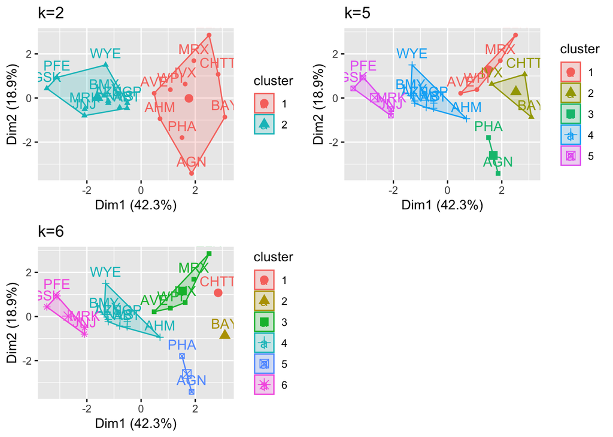

```r
kmeans_ss <- kmeans(phram2, centers = 2, nstart = 30)
kmeans_ss1<- kmeans(phram2, centers = 5, nstart = 30)
kmeans_ss2<- kmeans(phram2, centers = 6, nstart = 30)
Plott12<-fviz_cluster(kmeans_ss, data = phram2)+ggtitle("k=2")
plott22<-fviz_cluster(kmeans_ss1, data = phram2)+ggtitle("k=5")
plott33<-fviz_cluster(kmeans_ss2, data = phram2)+ggtitle("k=6")
grid.arrange(Plott12,plott22,plott33, nrow = 2)
```

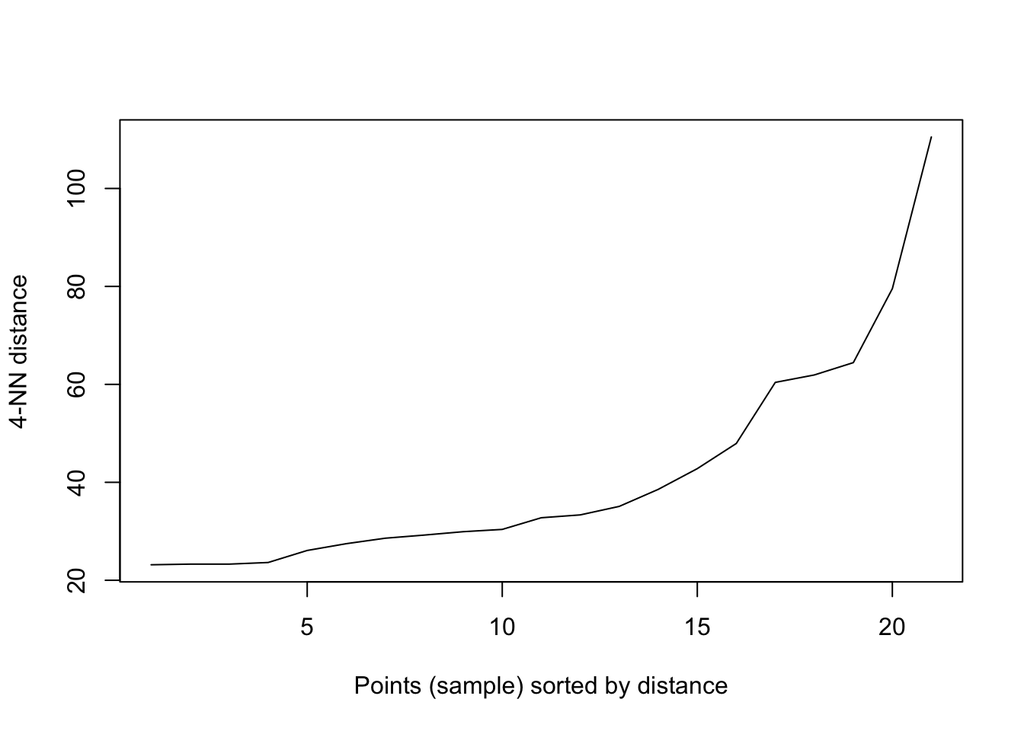

```r
#To get the best value of radius or eps.

# Graph to get the best value of radius at min points of 4.
dbscan::kNNdistplot(Phram, k=4)
```

```r
# DBSCAN Algorithm at eps=30 and minpts =4
db <- dbscan::dbscan(Phram, eps = 30, minPts = 4)

# Output of the clusters
print(db)
```

```
## DBSCAN clustering for 21 objects.
## Parameters: eps = 30, minPts = 4
## Using euclidean distances and borderpoints = TRUE
## The clustering contains 2 cluster(s) and 6 noise points.
##
## 0 1 2
## 6 8 7
##
## Available fields: cluster, eps, minPts, dist, borderPoints
```

```r
# To get which point belongs to which cluster
print(db$cluster)
```

```
##  [1] 1 0 2 1 1 2 1 2 2 1 0 2 0 2 0 1 0 0 1 2 1
```

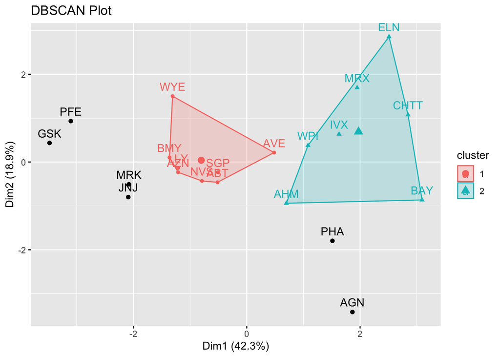

```r
# Visualization of clusters
fviz_cluster(db, Phram) + ggtitle("DBSCAN Plot")
```

#K-means is widely used in exploratory data analysis to find patterns and groupings in the data, and I chose it over DBSCAN because K-means clustering provides details about the financial profiles of pharmaceutical companies. DBSCAN may be useful in showing groups of companies having comparable financial characteristics, and these can aid in strategic decision-making and investment analysis for datasets with large regions. It is also simple to figure out. The K-means algorithm needs a certain amount of clusters, k. Because the user can decide how many clusters to build, this might be useful in some situations. The amount of clusters may not be simply identified via DBSCAN or hierarchical clustering.